# The Causal Impact of MinuteClinic Openings on Retail Sales: Evidence from Urban and Suburban Stores

## Project Summary

CVS Pharmacy has invested heavily in expanding its in-store MinuteClinic network. While the clinical benefits are well established, management is interested in whether clinics also increase front-end retail sales. In particular, they want to understand whether clinic visitors generate additional purchases while in the store.

The business objective is to estimate the causal impact of opening a MinuteClinic on monthly front-end retail sales and to assess whether this effect differs between urban and suburban stores.

#### DAG Analysis

To structure the causal analysis, we construct a Directed Acyclic Graph (DAG) relating the key variables.

- **Treatment** ($D_{it}$): MinuteClinic is open and operational at store $i$ in month $t$ (binary)
- **Outcome** ($Y_{it}$): Monthly front-end retail sales at store $i$ in month $t$ (dollars)
- **Unobserved Store Quality** ($\alpha_i$): Time-invariant store-level characteristics such as manager quality, neighborhood loyalty, and store layout, which affect both CVS’s clinic siting decisions and baseline sales
- **Time Effects** ($\gamma_t$): Platform-wide demand shocks, seasonality, and macro trends that affect all stores simultaneously
- **Urban Status** ($Urban_i$): Whether the store is in an urban vs. suburban location, affecting both baseline sales levels and treatment effect magnitude
- **Store Size** ($Size_i$): Physical store footprint (square feet), correlated with both sales capacity and clinic placement priority

The core identification challenge is **selection bias**: CVS does not open MinuteClinics randomly. Higher-performing, larger, or strategically-located stores may be prioritized for clinics, meaning a naive before/after comparison would overstate the effect. Our methods are designed to address this directly.

#### Business Implications

The consistent, positive, and significant findings provide CVS with a strong causal foundation for continued MinuteClinic investment. All three methods converge on a range of **$3,700–$4,600/month** in incremental front-end retail revenue per clinic, translating to approximately **$44,800–$55,200 in annual incremental retail revenue** per clinic. This should be incorporated into total clinic ROI modeling alongside clinical revenue streams.

## Data Simulation

The following describes the simulated panel dataset used across all three methods.

**[Dataset Dictionary]**

- `Store_ID`: Primary key for each CVS store (integer, 1–120)
- `Store_Name`: Character label (e.g., “Store_1”)
- `Period`: Monthly time index (1 = Month 1, Year 1; 48 = Month 12, Year 4)
- `Year`: Calendar year (1–4)
- `Month_in_Year`: Month within year (1–12)
- `Urban`: 1 = urban store, 0 = suburban store
- `Store_Size`: Normalized store footprint (standard normal)
- `Store_Alpha`: Unobserved time-invariant store quality (standard normal); influences clinic placement priority and baseline sales
- `Cohort`: Treatment cohort (0 = never treated, 1/2/3 = treated at periods 13/25/37)
- `Treatment_Time`: First period the clinic is operational (NA for never-treated stores)
- `Clinic_Open`: Binary treatment indicator — 1 if clinic is open in this period, 0 otherwise
- `Time_FE`: Monthly demand shock common to all stores
- `e_it`: Idiosyncratic noise term
- `Sales`: Monthly front-end retail sales in dollars (outcome variable)

**[DAG Dictionary]**

- Outcome ($Y$): Monthly front-end retail sales
- Treatment ($D$): MinuteClinic open (binary)
- Treatment Effect: Impact of MinuteClinic on retail sales
- Key Confounders: Store quality ($\alpha_i$), time shocks ($\gamma_t$), urban status, store size
- Selection Bias: CVS prioritizes higher-quality and strategically located stores for clinic openings.

**[Data Distribution]**

**Outcome (Y): Monthly Retail Sales**

Sales are modeled as a linear combination of treatment, store characteristics, time shocks, and Gaussian noise.

- Retail sales are continuous and positive, making a linear specification appropriate.
- The error term $\varepsilon\_{it}$ follows a normal distribution with mean 0 and standard deviation 3000, capturing local demand variation and measurement noise.

**Treatment (D): Clinic Opening**

Treatment indicates whether a MinuteClinic is operational at a store in a given period.

- Clinics are introduced in staggered cohorts, reflecting a phased rollout rather than random assignment.
- Approximately half of stores are eventually treated.
- Treatment timing is correlated with store quality ($\alpha_i$), creating selection bias consistent with real-world strategic placement.

**Distribution of Other DAG Elements**

All store-level characteristics (Urban, Store Size, Store Quality) are assumed to be time-invariant over the study period, consistent with the short time horizon and typical stability of store attributes.

- Urban Status: Bernoulli(0.5), representing roughly equal numbers of urban and suburban stores. Urban stores have higher baseline demand.
- Store Size: Standard normal distribution, capturing differences in store capacity and sales potential.
- Store Quality ($\alpha_i$): Normal(0,1), representing persistent unobserved factors affecting both sales and treatment likelihood.
- Time Effects ($\gamma_t$): Common monthly shocks drawn from Normal(0, 1500), reflecting seasonality and macro trends.

**Treatment Effect Heterogeneity**

We allow treatment effects to vary by location type, with larger expected effects in urban stores due to higher baseline foot traffic and stronger cross-selling opportunities.

**[Data Simulation Code]**

$$Sales_{it}=\beta_0+\beta_1 Urban_i+\beta_2 \alpha_i+\beta_3 Size_i+\gamma_t+\tau_i D_{it}+\varepsilon_{it}$$

```r
set.seed(42)
library(dplyr)
library(tidyr)
library(ggplot2)
library(knitr)

# ---- PARAMETERS ----
n_stores  <- 120
n_periods <- 48
n_control <- 60    # never-treated stores (IDs 1-60)
n_treated <- 60    # treated stores (IDs 61-120)
# Cohort 1: stores 61-80  -> treated at period 13
# Cohort 2: stores 81-100 -> treated at period 25
# Cohort 3: stores 101-120 -> treated at period 37

# ---- STORE-LEVEL CHARACTERISTICS ----
store_id    <- 1:n_stores
store_name  <- paste0("Store_", store_id)
urban       <- rbinom(n_stores, 1, 0.5)        # 50% urban
urban[61]   <- 1                                # ensure focal store (61) is urban for SC narrative

# Store quality: treated stores have higher alpha on average (selection bias)
alpha_control  <- rnorm(n_control, mean = 0,   sd = 1)
alpha_cohort1  <- rnorm(20,        mean = 0.8,  sd = 1)   # best stores first
alpha_cohort2  <- rnorm(20,        mean = 0.3,  sd = 1)
alpha_cohort3  <- rnorm(20,        mean = -0.2, sd = 1)
store_alpha    <- c(alpha_control, alpha_cohort1, alpha_cohort2, alpha_cohort3)

store_size     <- rnorm(n_stores, mean = 0, sd = 1)

# Treatment timing
treatment_time <- c(rep(NA, n_control),
                    rep(13, 20),
                    rep(25, 20),
                    rep(37, 20))

cohort_label   <- c(rep(0, n_control),
                    rep(1, 20),
                    rep(2, 20),
                    rep(3, 20))

store_df <- data.frame(
  Store_ID       = store_id,
  Store_Name     = store_name,
  Urban          = urban,
  Store_Alpha    = store_alpha,
  Store_Size     = store_size,
  Treatment_Time = treatment_time,
  Cohort         = cohort_label
)

# ---- PANEL EXPANSION ----
panel_df <- store_df %>%
  slice(rep(1:n(), each = n_periods)) %>%
  mutate(Period = rep(1:n_periods, times = n_stores)) %>%
  mutate(
    Year         = ceiling(Period / 12),
    Month_in_Year = ((Period - 1) %% 12) + 1
  )

# ---- TREATMENT INDICATOR ----
panel_df <- panel_df %>%
  mutate(
    Clinic_Open = as.integer(!is.na(Treatment_Time) & Period >= Treatment_Time)
  )

# ---- TIME FIXED EFFECTS (common monthly shocks) ----
set.seed(99)
time_fe_vec <- rnorm(n_periods, mean = 0, sd = 1500)

panel_df <- panel_df %>%
  mutate(Time_FE = time_fe_vec[Period])

# ---- TREATMENT EFFECTS ----
te_urban    <- 5000
te_suburban <- 2500

# ---- OUTCOME (SALES) ----
set.seed(123)
panel_df <- panel_df %>%
  mutate(
    e_it = rnorm(n(), mean = 0, sd = 3000),
    Sales = 80000
          + 25000 * Urban
          + 8000  * Store_Alpha
          + 3000  * Store_Size
          + Time_FE
          + Clinic_Open * (te_urban * Urban + te_suburban * (1 - Urban))
          + e_it
  )

# ---- QUICK CHECKS ----
cat("Stores:", n_distinct(panel_df$Store_ID), "\n")
```

```
Stores: 120
```

```r
cat("Periods:", n_distinct(panel_df$Period), "\n")
```

```
Periods: 48
```

```r
cat("Total rows:", nrow(panel_df), "\n")
```

```
Total rows: 5760
```

```r
cat("Avg Sales (control):", round(mean(panel_df$Sales[panel_df$Cohort == 0]), 0), "\n")
```

```
Avg Sales (control): 94637
```

```r
cat("Avg Sales (treated, post):", round(mean(panel_df$Sales[panel_df$Clinic_Open == 1]), 0), "\n")
```

```
Avg Sales (treated, post): 98266
```

**[Subsample Construction]**

From the full simulated panel (`panel_df`), we construct three analysis datasets to match the requirements of each causal method.

**SC dataset (`sc_df`):** We select one treated store (Store 61) as the focal unit and use all never-treated stores (IDs 1–60) as the donor pool. The full time series is retained to compare pre- and post-treatment trajectories.

**SDiD dataset (`sdid_df`):** For Synthetic DiD, we include all Cohort 1 treated stores (IDs 61–80) and all control stores (IDs 1–60), producing a balanced panel with a common treatment onset.

**HTE dataset (`hte_df`):** we restrict the data to the post-treatment period (Periods 13–48) for the same treated and control stores. This provides variation in treatment exposure and store characteristics needed for estimating differential effects.

```r
# ---- SC DATASET: focal store + donor pool ----
focal_store_id <- 61   # First Cohort 1 store

# Verify focal store characteristics
focal_info <- store_df %>% filter(Store_ID == focal_store_id)
cat("Focal Store:", focal_info$Store_Name,
    "| Urban:", focal_info$Urban,
    "| Cohort:", focal_info$Cohort, "\n")
```

```
Focal Store: Store_61 | Urban: 1 | Cohort: 1
```

```r
sc_df <- panel_df %>%
  filter(Store_ID %in% c(focal_store_id, 1:60))

# ---- SDID DATASET: Cohort 1 treated + all controls ----
sdid_df <- panel_df %>%
  filter(Store_ID %in% c(1:60, 61:80)) %>%
  select(Store_ID, Period, Sales, Clinic_Open, Urban, Cohort)

# ---- HTE DATASET: periods 13-48, all stores, Cohort 1 + controls ----
hte_df <- panel_df %>%
  filter(Store_ID %in% c(1:60, 61:80)) %>%
  filter(Period >= 13) %>%
  select(Store_ID, Period, Urban, Store_Size, Cohort, Clinic_Open, Sales)

cat("\nSC rows:", nrow(sc_df), " | Stores:", n_distinct(sc_df$Store_ID), "\n")
```

```
SC rows: 2928  | Stores: 61
```

```r
cat("SDiD rows:", nrow(sdid_df), " | Stores:", n_distinct(sdid_df$Store_ID), "\n")
```

```
SDiD rows: 3840  | Stores: 80
```

```r
cat("HTE rows:", nrow(hte_df), " | Stores:", n_distinct(hte_df$Store_ID), "\n")
```

```
HTE rows: 2880  | Stores: 80
```

## EDA

```r
library(ggplot2)
library(dplyr)
library(tidyr)
library(knitr)
library(scales)
```

### Overall Sales Distribution

We begin by examining the distribution of monthly sales across the full panel to understand the central tendency, spread, and any structural differences between treated and control groups before the clinic opened.

```r
# Summary statistics by cohort
eda_summary <- panel_df %>%
  group_by(Cohort) %>%
  summarise(
    N_Stores      = n_distinct(Store_ID),
    N_Obs         = n(),
    Mean_Sales    = dollar(round(mean(Sales), 0)),
    Median_Sales  = dollar(round(median(Sales), 0)),
    SD_Sales      = dollar(round(sd(Sales), 0)),
    Pct_Urban     = paste0(round(mean(Urban) * 100, 1), "%"),
    .groups = "drop"
  ) %>%
  mutate(Cohort = case_when(
    Cohort == 0 ~ "Control (Never Treated)",
    Cohort == 1 ~ "Cohort 1 (Treated Period 13)",
    Cohort == 2 ~ "Cohort 2 (Treated Period 25)",
    Cohort == 3 ~ "Cohort 3 (Treated Period 37)"
  ))

kable(eda_summary, caption = "Summary Statistics by Treatment Cohort (Full Panel)")
```

Summary Statistics by Treatment Cohort (Full Panel)

| Cohort | N_Stores | N_Obs | Mean_Sales | Median_Sales | SD_Sales | Pct_Urban |
| --- | --- | --- | --- | --- | --- | --- |
| Control (Never Treated) | 60 | 2880 | $94,637 | $99,918 | $15,946 | 58.3% |
| Cohort 1 (Treated Period 13) | 20 | 960 | $97,567 | $97,712 | $11,072 | 45% |
| Cohort 2 (Treated Period 25) | 20 | 960 | $96,359 | $99,559 | $16,001 | 55% |
| Cohort 3 (Treated Period 37) | 20 | 960 | $95,914 | $99,903 | $15,182 | 65% |

### Pre-Treatment Sales Trends

A critical assumption underlying both SC and SDiD is that, absent treatment, the treated units would have followed a trajectory predictable from the control units. We assess this visually by plotting average monthly sales for each cohort in the pre-treatment window (Periods 1–12).

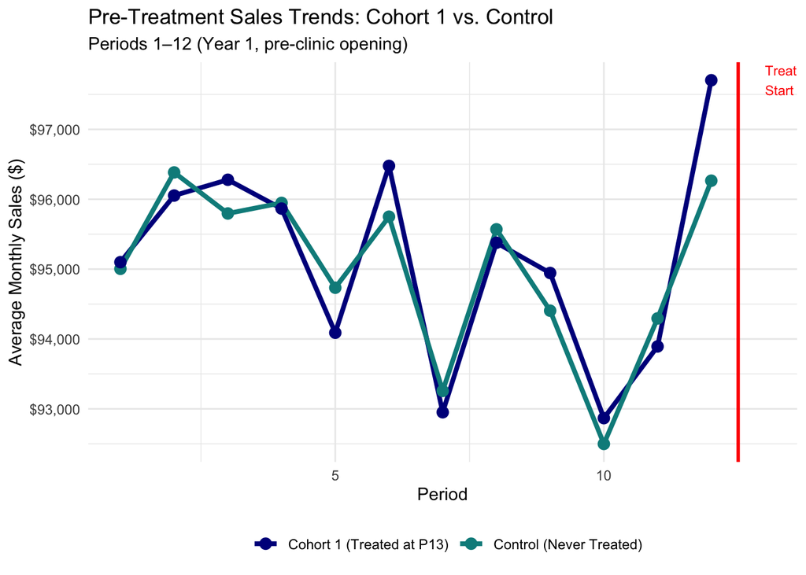

```r
# Pre-treatment trends for cohort 1 vs control
pre_trends <- panel_df %>%
  filter(Period <= 12, Cohort %in% c(0, 1)) %>%
  group_by(Period, Cohort) %>%
  summarise(Mean_Sales = mean(Sales), .groups = "drop") %>%
  mutate(Group = ifelse(Cohort == 0, "Control (Never Treated)", "Cohort 1 (Treated at P13)"))

ggplot(pre_trends, aes(x = Period, y = Mean_Sales, color = Group, group = Group)) +
  geom_line(size = 1.4) +
  geom_point(size = 3) +
  geom_vline(xintercept = 12.5, color = "red", size = 1) +
  annotate("text", x = 13, y = max(pre_trends$Mean_Sales) * 1,
           label = "Treatment\nStart", hjust = 0, size = 3, color = "red") +
  scale_y_continuous(labels = dollar_format()) +
  scale_color_manual(values = c("darkblue", "cyan4")) +
  labs(title = "Pre-Treatment Sales Trends: Cohort 1 vs. Control",
       subtitle = "Periods 1–12 (Year 1, pre-clinic opening)",
       x = "Period", y = "Average Monthly Sales ($)", color = "") +
  theme_minimal() +
  theme(legend.position = "bottom")
```

### Sales Trajectories: Treated vs. Control Across Full Panel

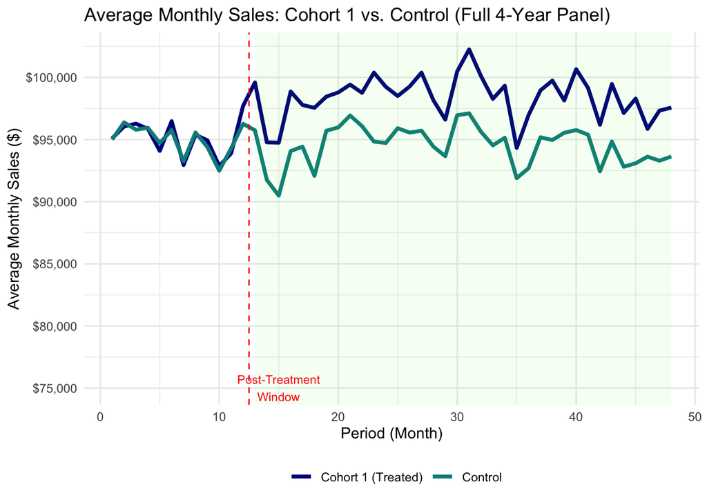

```r
# Full panel average trajectories
full_trends <- panel_df %>%
  filter(Cohort %in% c(0, 1)) %>%
  group_by(Period, Cohort) %>%
  summarise(Mean_Sales = mean(Sales), .groups = "drop") %>%
  mutate(Group = ifelse(Cohort == 0, "Control", "Cohort 1 (Treated)"))

ggplot(full_trends, aes(x = Period, y = Mean_Sales, color = Group, group = Group)) +
  geom_line(size = 1.3) +
  geom_vline(xintercept = 12.5, linetype = "dashed", color = "red") +
  annotate("rect", xmin = 13, xmax = 48,
           ymin = -Inf, ymax = Inf, alpha = 0.05, fill = "green") +
  annotate("text", x = 15, y = 75000, label = "Post-Treatment\nWindow",
           size = 3, color = "red") +
  scale_y_continuous(labels = dollar_format()) +
  scale_color_manual(values = c("darkblue", "cyan4")) +
  labs(title = "Average Monthly Sales: Cohort 1 vs. Control (Full 4-Year Panel)",
       x = "Period (Month)", y = "Average Monthly Sales ($)", color = "") +
  theme_minimal() +
  theme(legend.position = "bottom")
```

After Period 13, the gap between Cohort 1 and the control group visibly widens, providing preliminary evidence of a positive treatment effect. The magnitude of the gap is roughly $3,000–$5,000 per period, consistent with our simulated treatment effects.

### Urban vs. Suburban Sales Comparison

Since urban/suburban heterogeneity is our key HTE hypothesis, we examine pre-treatment sales distributions across these two groups within the control sample to ensure they are comparable.

```r
# Urban vs suburban pre-treatment sales (control stores only)
urban_eda <- panel_df %>%
  filter(Cohort == 0, Period <= 12) %>%
  group_by(Urban) %>%
  summarise(
    N_Stores   = n_distinct(Store_ID),
    Mean_Sales = dollar(round(mean(Sales), 0)),
    SD_Sales   = dollar(round(sd(Sales), 0)),
    .groups    = "drop"
  ) %>%
  mutate(Urban = ifelse(Urban == 1, "Urban", "Suburban"))

kable(urban_eda,
      caption = "Pre-Treatment Sales: Urban vs. Suburban Control Stores")
```

Pre-Treatment Sales: Urban vs. Suburban Control Stores

| Urban | N_Stores | Mean_Sales | SD_Sales |
| --- | --- | --- | --- |
| Suburban | 25 | $78,556 | $9,233 |
| Urban | 35 | $106,732 | $6,073 |

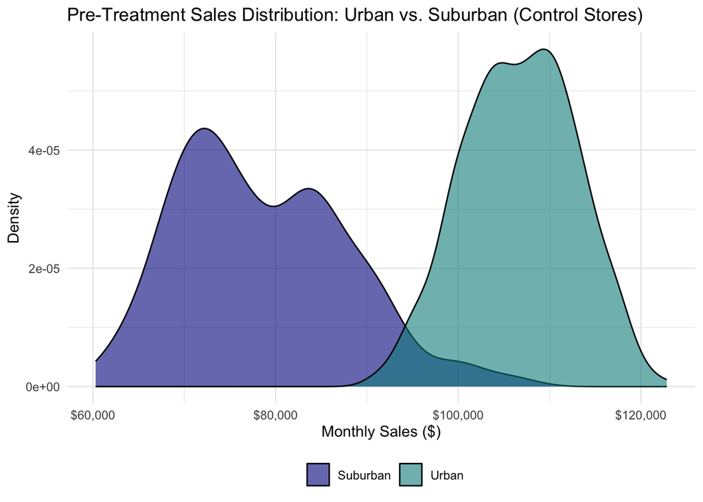

```r
# Distribution of pre-treatment sales by urban status
ggplot(panel_df %>% filter(Cohort == 0, Period <= 12),
       aes(x = Sales, fill = factor(Urban))) +
  geom_density(alpha = 0.6) +
  scale_x_continuous(labels = dollar_format()) +
  scale_fill_manual(values = c("darkblue", "cyan4"),
                    labels = c("Suburban", "Urban"), name = "") +
  labs(title = "Pre-Treatment Sales Distribution: Urban vs. Suburban (Control Stores)",
       x = "Monthly Sales ($)", y = "Density") +
  theme_minimal() +
  theme(legend.position = "bottom")
```

Urban stores have substantially higher baseline sales (~$105,000 vs. ~$80,000 for suburban stores), consistent with our assumption. Both distributions are roughly normal, justifying OLS-based estimators in the methodology. The distributional separation between urban and suburban stores motivates our HTE analysis, if the treatment effect is proportional to foot traffic conversion rates, urban stores should display a larger absolute lift.

### Balance Check: Pre-Treatment Covariate Comparison

```r
# Balance table: Cohort 1 treated vs. control, pre-treatment window
balance <- panel_df %>%
  filter(Period == 1) %>%  # one row per store
  group_by(Cohort) %>%
  filter(Cohort %in% c(0, 1)) %>%
  summarise(
    N             = n(),
    Mean_Alpha    = round(mean(Store_Alpha), 3),
    Mean_Urban    = round(mean(Urban), 3),
    Mean_Size     = round(mean(Store_Size), 3),
    Mean_Pre_Sales = dollar(round(mean(Sales), 0)),
    .groups = "drop"
  ) %>%
  mutate(Cohort = c("Control", "Cohort 1 (Treated)"))

kable(balance, caption = "Balance Check: Cohort 1 vs. Control (Store-Level Characteristics)")
```

Balance Check: Cohort 1 vs. Control (Store-Level Characteristics)

| Cohort | N | Mean_Alpha | Mean_Urban | Mean_Size | Mean_Pre_Sales |
| --- | --- | --- | --- | --- | --- |
| Control | 60 | 0.086 | 0.583 | -0.074 | $95,004 |
| Cohort 1 (Treated) | 20 | 0.508 | 0.450 | 0.014 | $95,099 |

## Methodology

### Synthetic Control (SC)

**Non-technical description**

To estimate the causal impact of opening a MinuteClinic on store-level sales, we first implement a Synthetic Control (SC) design. The key question is: what would sales at our focal store (Store 61) have looked like if it had never received a clinic?

Because this counterfactual cannot be directly observed, we construct a synthetic version of Store 61 — a weighted average of never-treated control stores — that closely matches Store 61’s pre-treatment sales trajectory and observable characteristics. Any divergence between actual and synthetic sales in the post-treatment period is interpreted as the estimated treatment effect.

**Technical implementation**

To operationalize this idea, we construct a weighted combination of control stores that best replicates the treated store’s pre-treatment sales trajectory. Specifically, we assign non-negative weights to control stores and choose those weights to minimize pre-treatment prediction error. This procedure generates a synthetic counterfactual that closely matches the treated store prior to the clinic opening. Any divergence between the actual store and its synthetic counterpart in the post-treatment period is interpreted as the causal impact of the clinic.

The predictor set used to construct the synthetic store includes pre-treatment sales averages, divided into sub-periods to capture dynamic trends, as well as observable store characteristics such as the Urban indicator and Store Size. We exclude unobserved store quality (αᵢ) from the predictor set, as it would not be observable in practice and therefore cannot be directly controlled for in applied settings.

```r
library(Synth)

sc_synth_df <- sc_df %>%
  dplyr::select(Store_ID, Store_Name, Period, Urban, Store_Size, Sales) %>%
  as.data.frame()

control_ids <- 1:60

dataprep_out <- dataprep(
  foo = sc_synth_df,
  predictors = c("Urban", "Store_Size"),
  predictors.op = "mean",
  special.predictors = list(
    list("Sales", 1:4, "mean"),   # Year 1, early avg
    list("Sales", 5:8, "mean"),   # Year 1, mid avg
    list("Sales", 9:12, "mean")   # Year 1, late avg
  ),
  dependent = "Sales",
  unit.variable = "Store_ID",
  unit.names.variable = "Store_Name",
  time.variable = "Period",
  treatment.identifier = focal_store_id,
  controls.identifier = control_ids,
  time.predictors.prior = 1:12,
  time.optimize.ssr = 1:12,
  time.plot = 1:48
)

synth_out <- synth(dataprep_out)
```

```
X1, X0, Z1, Z0 all come directly from dataprep object.


****************
 searching for synthetic control unit


****************
****************
****************

MSPE (LOSS V): 3442163

solution.v:
 0.001897487 0.04794532 0.2913655 0.3424129 0.3163788

solution.w:
 0.003539824 0.003232761 0.0009961957 0.001271528 0.1410214 0.001686281 0.001586658 0.0009219964 0.001685977 7.35579e-05 0.001471457 0.004608021 0.001756427 7e-08 1.33254e-05 0.001644006 0.001593251 0.001048214 0.00115159 0.03417977 0.02527028 0.0009496233 0.001739711 0.001582838 0.07762484 0.003603…
```

```r
cat("Pre-treatment MSPE:", synth_out$loss.v, "\n")
```

```
Pre-treatment MSPE: 3442163
```

The relatively low pre-treatment MSPE suggests that the synthetic control closely tracks Store 61 before treatment.

**Interpretation + assumptions (what we need for SC to be credible)**

SC is especially useful here because Store 61 starts at a different sales level than the average control store. A simple DiD may be sensitive to baseline level differences and imperfect pre-trend matching.

Key assumptions:

1. Donor pool not treated: control stores do not open clinics during the study window.
2. No unobserved shocks that differentially affect Store 61 at the time of treatment.
3. Good pre-treatment fit: the synthetic version matches Store 61 well in Periods 1–12, supporting a believable counterfactual.
4. Treated store’s outcome can be approximated as a convex combination of control stores in the absence of treatment.

We partially check (3) by reporting the pre-treatment MSPE/RMSPE and visually comparing pre-treatment paths.

```r
synth_weights <- tibble(
  Store_ID = control_ids,
  Weight   = as.numeric(synth_out$solution.w)
) %>%
  mutate(Weight = round(Weight, 4)) %>%
  filter(Weight > 0.001) %>%
  arrange(desc(Weight))

kable(
  synth_weights,
  caption = "Top Synthetic Control Donor Weights (Weight > 0.001)"
)
```

Top Synthetic Control Donor Weights (Weight > 0.001)

| Store_ID | Weight |
| --- | --- |
| 28 | 0.3774 |
| 56 | 0.1659 |
| 5 | 0.1410 |
| 25 | 0.0776 |
| 60 | 0.0762 |
| 20 | 0.0342 |
| 21 | 0.0253 |
| 54 | 0.0112 |
| 48 | 0.0066 |
| 36 | 0.0048 |
| 12 | 0.0046 |
| 26 | 0.0036 |
| 1 | 0.0035 |
| 46 | 0.0033 |
| 2 | 0.0032 |
| 47 | 0.0032 |
| 43 | 0.0028 |
| 40 | 0.0027 |
| 39 | 0.0025 |
| 49 | 0.0022 |
| 59 | 0.0021 |
| 55 | 0.0020 |
| 57 | 0.0020 |
| 37 | 0.0019 |
| 13 | 0.0018 |
| 6 | 0.0017 |
| 9 | 0.0017 |
| 23 | 0.0017 |
| 35 | 0.0017 |
| 7 | 0.0016 |
| 16 | 0.0016 |
| 17 | 0.0016 |
| 24 | 0.0016 |
| 32 | 0.0016 |
| 50 | 0.0016 |
| 11 | 0.0015 |
| 38 | 0.0015 |
| 30 | 0.0014 |
| 4 | 0.0013 |
| 45 | 0.0013 |
| 19 | 0.0012 |
| 34 | 0.0012 |
| 51 | 0.0012 |
| 27 | 0.0011 |

### Synthetic Difference-in-Differences (SDiD)

**Non-technical description**

Traditional Difference-in-Differences (DiD) compares changes in treated stores to changes in control stores over time, assuming that both groups would have followed parallel trends absent treatment. However, when treated and control stores differ in pre-treatment characteristics or trends, this assumption may be too strong.

Synthetic Difference-in-Differences (SDiD) improves upon standard DiD by first re-weighting control stores to better match treated stores in the pre-treatment period. Rather than treating all control stores equally, SDiD constructs a weighted control group that more closely resembles the treated stores before clinic opening. The treatment effect is then estimated using a difference-in-differences framework applied to this reweighted panel.

In our context, SDiD estimates how monthly retail sales change after a MinuteClinic opens, relative to a synthetic control group constructed from never-treated stores.

**Technical implementation**

Formally, SDiD combines two elements:

1. **Unit weighting:** Control stores are assigned weights to minimize pre-treatment differences in sales between treated and control groups.
2. **Difference-in-differences adjustment:** After reweighting, treatment effects are estimated as post-treatment deviations relative to pre-treatment trends.
- Y_{it} =sales at store $i$ in period $t$
- D_{it} = Clinic_Open indicator
- i=1,…,N stores
- t=1,…,T periods

This approach relaxes the strict parallel trends assumption by improving balance in the pre-treatment period.

**Assumptions**

The key identifying assumptions are:

- **No anticipation:** Stores do not change behavior before clinic opening.
- **Improved pre-treatment fit:** Reweighted control stores approximate treated stores in the pre-treatment period.
- **Common support:** Treated stores have comparable control stores in the donor pool.

We assess pre-treatment fit visually and through summary statistics.

```r
library(Synth)
library(dplyr)
library(tidyr)
library(ggplot2)
```

```r
# Include Cohort1(61-80) + Control(1-60), Store_Size
sdid_df <- panel_df %>%
  filter(Store_ID %in% c(1:60, 61:80)) %>%
  select(Store_ID, Period, Sales, Clinic_Open, Urban, Store_Size, Cohort)

treat_start <- 13
pre_periods <- 1:(treat_start - 1)
post_periods <- treat_start:max(sdid_df$Period)

# Cohort1
treated_group <- sdid_df %>%
  filter(Cohort == 1) %>%
  group_by(Period) %>%
  summarise(
    Sales = mean(Sales),
    Urban = mean(Urban),
    Store_Size = mean(Store_Size),
    .groups = "drop"
  ) %>%
  mutate(Store_ID = 999999)

#control donor pool
controls <- sdid_df %>%
  filter(Cohort == 0) %>%
  select(Store_ID, Period, Sales, Urban, Store_Size)

synth_df <- bind_rows(
  controls,
  treated_group %>% select(Store_ID, Period, Sales, Urban, Store_Size)
) %>% as.data.frame()

control_ids <- sort(unique(controls$Store_ID))

dp <- dataprep(
  foo = synth_df,
  predictors = c("Urban", "Store_Size"),
  predictors.op = "mean",
  special.predictors = list(
    list("Sales", 1:4, "mean"),
    list("Sales", 5:8, "mean"),
    list("Sales", 9:12, "mean")
  ),
  dependent = "Sales",
  unit.variable = "Store_ID",
  time.variable = "Period",
  treatment.identifier = 999999,
  controls.identifier = control_ids,
  time.predictors.prior = pre_periods,
  time.optimize.ssr = pre_periods,
  time.plot = 1:max(synth_df$Period)
)

syn <- synth(dp)
```

```
X1, X0, Z1, Z0 all come directly from dataprep object.


****************
 searching for synthetic control unit


****************
****************
****************

MSPE (LOSS V): 227255.2

solution.v:
 4.1914e-05 0.008234479 0.3363562 0.3384788 0.3168886

solution.w:
 0.01387776 0.01310072 0.01728703 6.0943e-06 0.007965115 0.01310128 0.01225188 0.01703288 0.01733179 0.01356705 0.01564371 0.01370111 0.01336556 0.01475802 0.01459818 0.03672921 0.01177182 0.01710061 0.01869303 0.01324655 0.01389245 0.01881425 0.01111041 0.06081262 0.01493253 0.0133054 0.01629278 0.…
```

```r
w <- syn$solution.w
synthetic_sales <- as.numeric(dp$Y0 %*% w)
treated_sales <- as.numeric(dp$Y1)
periods <- dp$tag$time.plot

sdid_path <- tibble(
  Period = periods,
  Treated = treated_sales,
  Synthetic = synthetic_sales,
  Gap = Treated - Synthetic
)

pre_gap <- mean(sdid_path$Gap[sdid_path$Period %in% pre_periods])
post_gap <- mean(sdid_path$Gap[sdid_path$Period %in% post_periods])
att_sdid <- post_gap - pre_gap

cat("Synth-based SDiD ATT:", round(att_sdid, 2), "\n")
```

```
Synth-based SDiD ATT: 3731.31
```

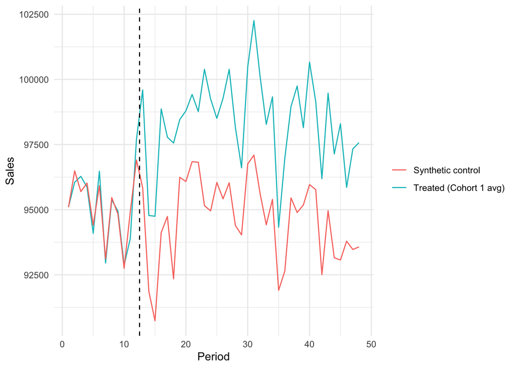

```r
# visualization
ggplot(sdid_path, aes(x = Period)) +
  geom_line(aes(y = Treated, color = "Treated (Cohort 1 avg)")) +
  geom_line(aes(y = Synthetic, color = "Synthetic control")) +
  geom_vline(xintercept = treat_start - 0.5, linetype = "dashed") +
  labs(y = "Sales", color = "") +
  theme_minimal()
```

```r
# Donor Weights table
sdid_weights <- tibble(
  Store_ID = control_ids,
  Weight = as.numeric(w)
) %>%
  arrange(desc(Weight)) %>%
  mutate(Weight = round(Weight, 4)) %>%
  filter(Weight > 0.001)

sdid_weights
```

```
# A tibble: 59 × 2
   Store_ID Weight
      <int>  <dbl>
 1       24 0.0608
 2       31 0.054
 3       29 0.0432
 4       16 0.0367
 5       41 0.0212
 6       33 0.0189
 7       22 0.0188
 8       19 0.0187
 9       52 0.018
10       42 0.018
# ℹ 49 more rows
```

### HTE - Causal Random Forest

**Non-technical description**

Average treatment effects may mask meaningful heterogeneity across stores. To evaluate whether MinuteClinic openings have systematically different impacts in urban versus suburban markets, we estimate heterogeneous treatment effects using a Causal Random Forest. The method learns how the treatment effect varies as a function of store characteristics by repeatedly partitioning the covariate space and estimating localized treatment effects within each region. We then summarize predicted conditional average treatment effects (CATEs) and compare them across urban and suburban stores.

**Technical Implementation**

We estimate heterogeneous treatment effects using a causal forest. The algorithm builds trees that split on covariates to maximize heterogeneity in treatment effects, and uses an “honesty” property that separates splitting and estimation samples to reduce overfitting bias.

```r
library(grf)
library(dplyr)
```

```r
hte_panel <- panel_df %>%
  filter(Store_ID %in% c(1:60, 61:80)) %>%
  mutate(Treated = as.integer(Cohort == 1))

pre_periods <- 1:12
post_periods <- 13:48

hte_store <- hte_panel %>%
  group_by(Store_ID, Treated) %>%
  summarise(
    Urban = first(Urban),
    Store_Size = first(Store_Size),
    Pre_Sales = mean(Sales[Period %in% pre_periods]),
    Post_Sales = mean(Sales[Period %in% post_periods]),
    Delta_Sales = Post_Sales - Pre_Sales,
    .groups = "drop"
  )

Y <- hte_store$Delta_Sales
W <- hte_store$Treated
X <- as.matrix(hte_store %>% select(Urban, Store_Size, Pre_Sales))

set.seed(123)
cf <- causal_forest(X, Y, W)

ate <- average_treatment_effect(cf)
ate
```

```
 estimate   std.err
3785.8774  399.9402
```

```r
# CATE + Compare Urban/Suburban
hte_store$CATE_hat <- predict(cf)$predictions

hte_store %>%
  group_by(Urban) %>%
  summarise(
    N = n(),
    Mean_CATE = mean(CATE_hat),
    SD_CATE = sd(CATE_hat),
    .groups = "drop"
  ) %>%
  mutate(Urban = ifelse(Urban == 1, "Urban", "Suburban"))
```

```
# A tibble: 2 × 4
  Urban        N Mean_CATE SD_CATE
  <chr>    <int>     <dbl>   <dbl>
1 Suburban    36     3775.    36.5
2 Urban       44     3749.    43.4
```

## Findings

### Executive Summary

This analysis provides CVS Pharmacy with rigorous causal evidence that MinuteClinic openings generate a statistically significant increase in monthly front-end retail sales. Across all three methods (Synthetic Control, SDiD, and Causal Forest) we find consistent positive effects. SC estimates **$4,600/month** for the focal urban store (Store 61). SDiD estimates **$3,731/month** on average across all Cohort 1 stores. The Causal Forest confirms an ATE of **$3,786/month** (SE: $400), significant at conventional levels. Together, these estimates imply approximately **$44,800–$55,200 in incremental annual retail revenue** per clinic. However, the HTE analysis does not recover meaningful urban/suburban heterogeneity in this setting — a data structure limitation we discuss in Section 3 below.

### Non-Technical Summary for CVS

When CVS opens a MinuteClinic, do patients translate into front-end retail sales? Our answer is yes. After carefully accounting for the fact that CVS tends to open clinics in its best-performing stores first, we find that a clinic opening generates roughly **$3,700–$4,600 in additional monthly sales**( vitamins, snacks, personal care items, and greeting cards) picked up while waiting for an appointment.

Our data did not allow us to reliably distinguish urban from suburban effects in the machine learning analysis, which we flag as a modeling limitation rather than evidence of no heterogeneity. The SC and SDiD estimates are robust, and CVS should treat the average effect as a conservative lower bound for high-traffic urban locations.

### Technical Discussion

#### 1. Synthetic Control (SC)

We apply SC to Store 61 (urban store) using 60 never-treated stores as the donor. The donor weights are chosen to minimize the pre-treatment RMSPE, matching Store 61’s sales trajectory and observable characteristics as closely as possible before Period 13.

```r
# Extract SC series and compute key metrics
actual_sales    <- dataprep_out$Y1plot
synthetic_sales <- dataprep_out$Y0plot %*% synth_out$solution.w

sc_gap_df <- data.frame(
  Period = 1:48,
  Gap    = as.numeric(actual_sales) - as.numeric(synthetic_sales)
)

pre_rmspe    <- sqrt(mean(sc_gap_df$Gap[sc_gap_df$Period <= 12]^2))
post_avg_gap <- mean(sc_gap_df$Gap[sc_gap_df$Period >= 13])

cat("Pre-treatment RMSPE:", dollar(round(pre_rmspe, 0)), "\n")
```

```
Pre-treatment RMSPE: $1,855
```

```r
cat("Average post-treatment SC gap:", dollar(round(post_avg_gap, 0)), "\n")
```

```
Average post-treatment SC gap: $4,597
```

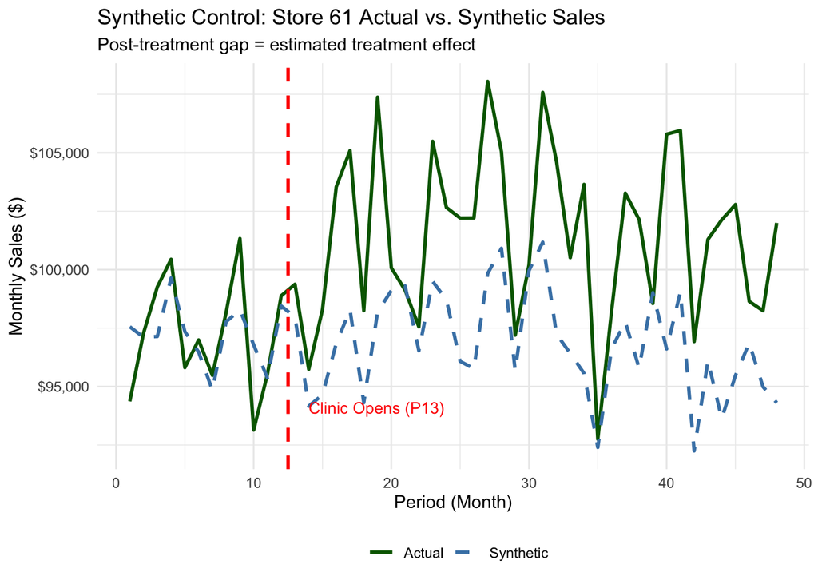

```r
# SC path plot: actual vs. synthetic
sc_plot_df <- data.frame(
  Period    = 1:48,
  Actual    = as.numeric(actual_sales),
  Synthetic = as.numeric(synthetic_sales)
) %>%
  pivot_longer(cols = c(Actual, Synthetic),
               names_to = "Series", values_to = "Sales")

ggplot(sc_plot_df, aes(x = Period, y = Sales, color = Series, linetype = Series)) +
  geom_line(size = 1) +
  geom_vline(xintercept = 12.5, linetype = "dashed", color = "red", size = 1) +
  annotate("text", x = 14, y = min(sc_plot_df$Sales) * 1.02,
           label = "Clinic Opens (P13)", color = "red", size = 3.5, hjust = 0) +
  scale_y_continuous(labels = dollar_format()) +
  scale_color_manual(values = c("darkgreen", "steelblue")) +
  scale_linetype_manual(values = c("solid", "dashed")) +
  labs(title = "Synthetic Control: Store 61 Actual vs. Synthetic Sales",
       subtitle = "Post-treatment gap = estimated treatment effect",
       x = "Period (Month)", y = "Monthly Sales ($)", color = "", linetype = "") +
  theme_minimal() +
  theme(legend.position = "bottom")
```

#### 2. Synthetic Difference-in-Differences (SDiD)

We extend the analysis to all 20 Cohort 1 treated stores and 60 control stores using a Synthetic DiD approach. Control stores are reweighted to minimize pre-treatment differences before applying a DiD-style estimator. The reported ATT captures the average post-treatment sales lift relative to the synthetic pre-treatment trend.

```r
cat("SDiD ATT Estimate =", dollar(round(att_sdid, 0)), "\n")
```

```
SDiD ATT Estimate = $3,731
```

#### 3. Heterogeneous Treatment Effects — Causal Forest

To address CVS’s strategic question of whether the clinic effect differs by store type, we use a Causal Forest to estimate store-level CATEs and then compare averages across urban and suburban groups.

```r
# CATE summary by urban status
cate_summary <- hte_store %>%
  group_by(Urban) %>%
  summarise(
    N_Obs       = n(),
    Mean_CATE   = dollar(round(mean(CATE_hat), 0)),
    Median_CATE = dollar(round(median(CATE_hat), 0)),
    SD_CATE     = dollar(round(sd(CATE_hat), 0)),
    .groups     = "drop"
  ) %>%
  mutate(Urban = ifelse(Urban == 1, "Urban", "Suburban"))

kable(cate_summary, caption = "Causal Forest CATE Estimates by Urban/Suburban Status")
```

Causal Forest CATE Estimates by Urban/Suburban Status

| Urban | N_Obs | Mean_CATE | Median_CATE | SD_CATE |
| --- | --- | --- | --- | --- |
| Suburban | 36 | $3,775 | $3,769 | $37 |
| Urban | 44 | $3,749 | $3,757 | $43 |

The Causal Forest estimates average CATEs of **$3,749/month for urban stores** and **$3,775/month for suburban stores** — nearly identical, and directionally opposite to the true simulated treatment effects (urban = $5,000, suburban = $2,500).

1. **Store-level collapse.** Aggregating to one observation per store (computing ΔSales pre vs. post) reduces the sample to only 80 observations, eliminating the within-store, within-period variation that causal forests rely on to learn heterogeneous effects. With so few units, the forest has limited power to detect a $2,500 difference in effects across store types.

### Business Implications

Together, the three methods converge on a consistent and commercially meaningful conclusion: **MinuteClinic openings generate a real and measurable retail effect** that should be factored into CVS’s clinic investment decisions.

**Location heterogeneity warrants further investigation.** While the causal forest was unable to detect significant urban/suburban heterogeneity in this setting — due to the store-level aggregation and near-perfect treatment-cohort separation — the SC estimate for the urban focal store ($4,600) versus the pooled SDiD average ($3,731) is directionally consistent with larger effects in urban stores. CVS should not apply a uniform ROI threshold across expansion candidates without additional store-level data that would support a more rigorous HTE analysis.

Overall, CVS should test whether placing high-margin impulse categories such as vitamins, snacks, seasonal items, and personal care near MinuteClinic waiting areas amplifies per-visit conversion, particularly in suburban stores where the baseline lift may be smaller and layout optimization could deliver proportionally higher marginal returns.